# L01 Visualization

### Exercise 3

Construct a scatterplot of `hwy` versus `cty`. Set the color of the points to `drv`.

Now construct a scatterplot of `hwy` versus `cty`. Set the color of the points to your favorite color (try typing `colors()` in the console) and `facet` by `drv`. Read `?facet_wrap` and adjust the `ncol` and `scales` as necessary.

**Solution**

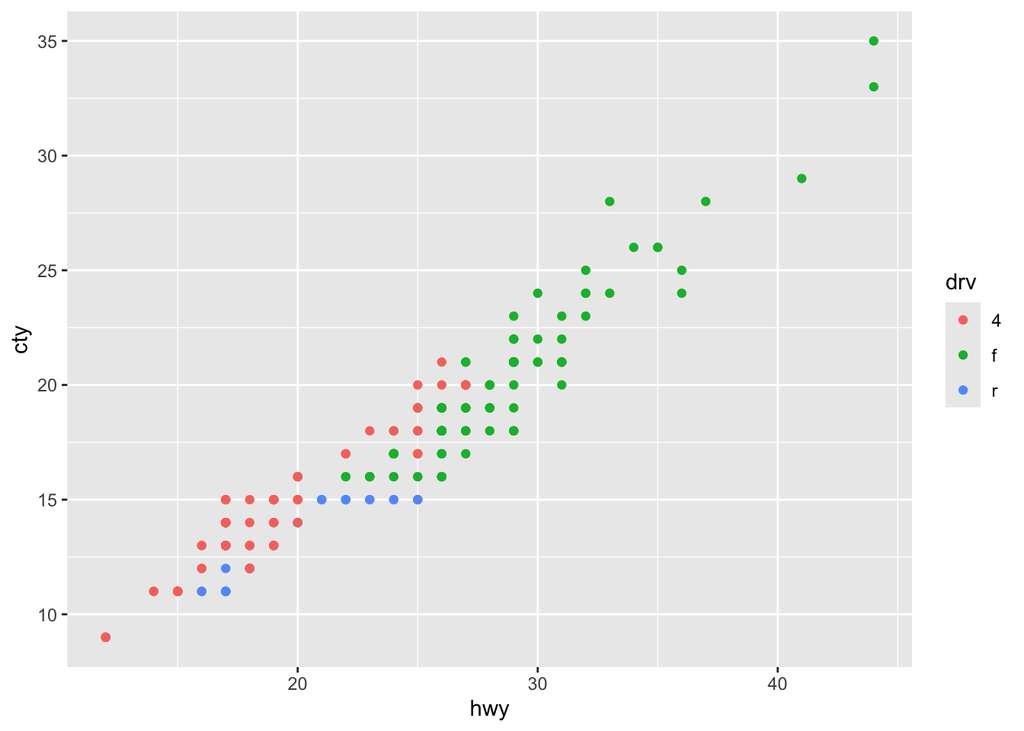

```r
# scatterplot of hwy vs cty, color set by drv
ggplot(
  data = mpg,
  mapping = aes(x = hwy, y = cty, color = drv)
) +
  geom_point()
```

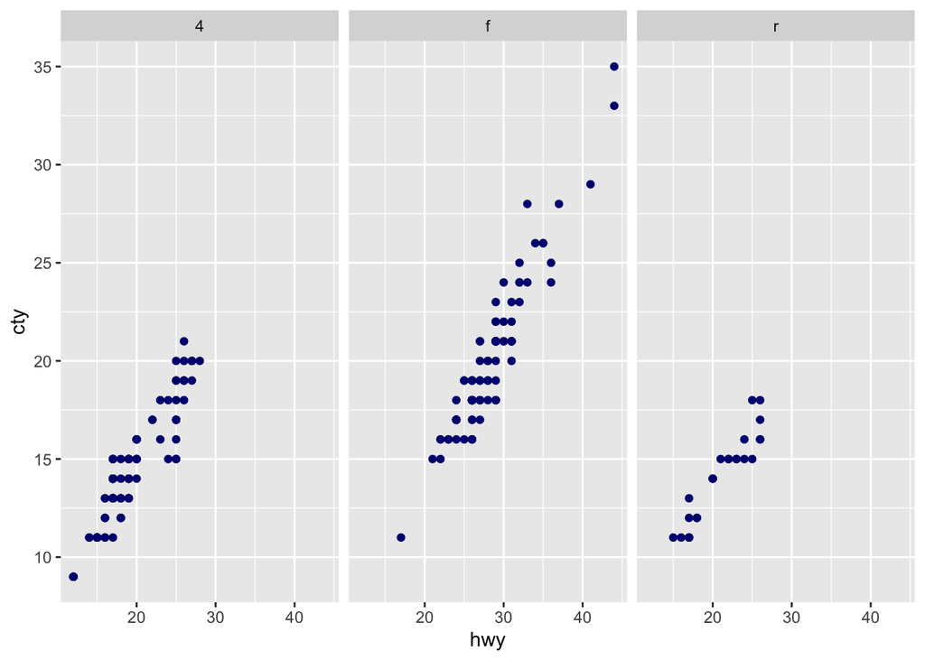

```r
# scatterplot of hwy vs cty, faceted by drv with favorite color
ggplot(
  data = mpg,
  mapping = aes(x = hwy, y = cty, color = drv)
) +
  geom_point(color = "navy") +
  facet_wrap(~ drv, ncol = 3)
```

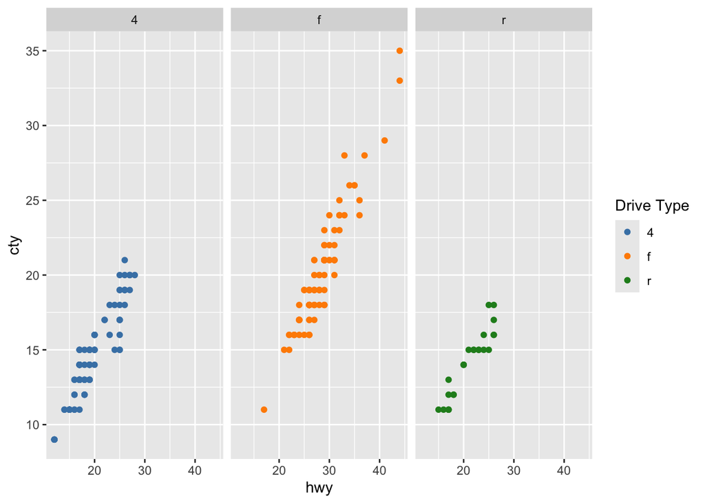

```r
# scatterplot of hwy vs cty, faceted by drv each with different colors
ggplot(
  data = mpg,
  mapping = aes(x = hwy, y = cty, color = drv) # map color to drv
) +
  geom_point() +
  facet_wrap(~ drv) +
  scale_color_manual(values = c("4" = "steelblue",      # manually assign colors
                                "f" = "darkorange",
                                "r" = "forestgreen")) +
  labs(color = "Drive Type") # renaming the legend title
```

What are the advantages to using faceting instead of the color aesthetic? What are the disadvantages? How might the balance change if you had a larger dataset?

**Solution**

Faceting provides can provide clarity within each category while color allows for easier comparison between categories on a shared plot leaving the choice as a trade-off. Faceting is better at showing each category’s unique data distribution by eliminating overplotting between the groups, though this separation makes it harder to compare specific data points directly. Conversely, using color on a shared plot allows for easy point-for-point comparison, but its utility is quickly compromised by overplotting, which can obscure the data’s true density.

This balance shifts significantly depending on how a data set is “larger.” If the data set is large due to a high number of data points, the advantage moves toward faceting. Severe overplotting would render a single colored plot unreadable, while faceting maintains clarity for each group’s underlying pattern, while noting that overplotting can still occur within each facet, which would still require other techniques like transparency or jitter.

However, if the dataset is large due to a high number of categories, faceting can then start to get out of hand. Displaying too many facets, such as 20 or more can lead to cognitive overload and makes each plot too small to be useful. At this point, it might be beneficial to explore other strategies of representing the data.